# Red Wine Quality Exploration by Hani Jubail

```
## [1] "C:/Users/PC/Desktop/R"
```

> **introduction**: The dataset were created, using red wine samples. The inputs include objective tests (e.g. PH values) and the output is based on sensory data (median of at least 3 evaluations made by wine experts). Each expert graded the wine quality between 0 (very bad) and 10 (very excellent).

# Univariate Plots Section

```
##   X fixed.acidity volatile.acidity citric.acid residual.sugar chlorides
## 1 1           7.4             0.70        0.00            1.9     0.076
## 2 2           7.8             0.88        0.00            2.6     0.098
## 3 3           7.8             0.76        0.04            2.3     0.092
## 4 4          11.2             0.28        0.56            1.9     0.075
## 5 5           7.4             0.70        0.00            1.9     0.076
## 6 6           7.4             0.66        0.00            1.8     0.075
##   free.sulfur.dioxide total.sulfur.dioxide density   pH sulphates alcohol
## 1                  11                   34  0.9978 3.51      0.56     9.4
## 2                  25                   67  0.9968 3.20      0.68     9.8
## 3                  15                   54  0.9970 3.26      0.65     9.8
## 4                  17                   60  0.9980 3.16      0.58     9.8
## 5                  11                   34  0.9978 3.51      0.56     9.4
## 6                  13                   40  0.9978 3.51      0.56     9.4
##   quality
## 1       5
## 2       5
## 3       5
## 4       6
## 5       5
## 6       5
```

> The quality must be converted into factors because it is a categorical variable .

```
##   X fixed.acidity volatile.acidity citric.acid residual.sugar chlorides
## 1 1           7.4             0.70        0.00            1.9     0.076
## 2 2           7.8             0.88        0.00            2.6     0.098
## 3 3           7.8             0.76        0.04            2.3     0.092
## 4 4          11.2             0.28        0.56            1.9     0.075
## 5 5           7.4             0.70        0.00            1.9     0.076
## 6 6           7.4             0.66        0.00            1.8     0.075
##   free.sulfur.dioxide total.sulfur.dioxide density   pH sulphates alcohol
## 1                  11                   34  0.9978 3.51      0.56     9.4
## 2                  25                   67  0.9968 3.20      0.68     9.8
## 3                  15                   54  0.9970 3.26      0.65     9.8
## 4                  17                   60  0.9980 3.16      0.58     9.8
## 5                  11                   34  0.9978 3.51      0.56     9.4
## 6                  13                   40  0.9978 3.51      0.56     9.4
##   quality
## 1       5
## 2       5
## 3       5
## 4       6
## 5       5
## 6       5
```

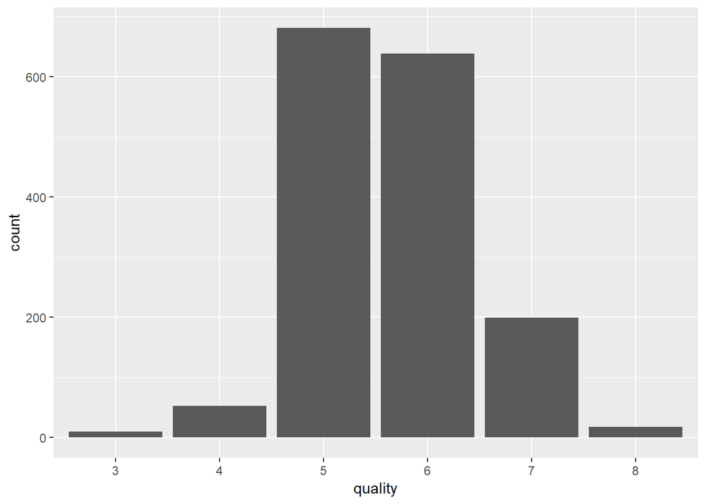

> Most of the red wine from the sample are of level 5 and 6 quality, with fewer samples of lesser-quality and higher levels at 7 or 8.

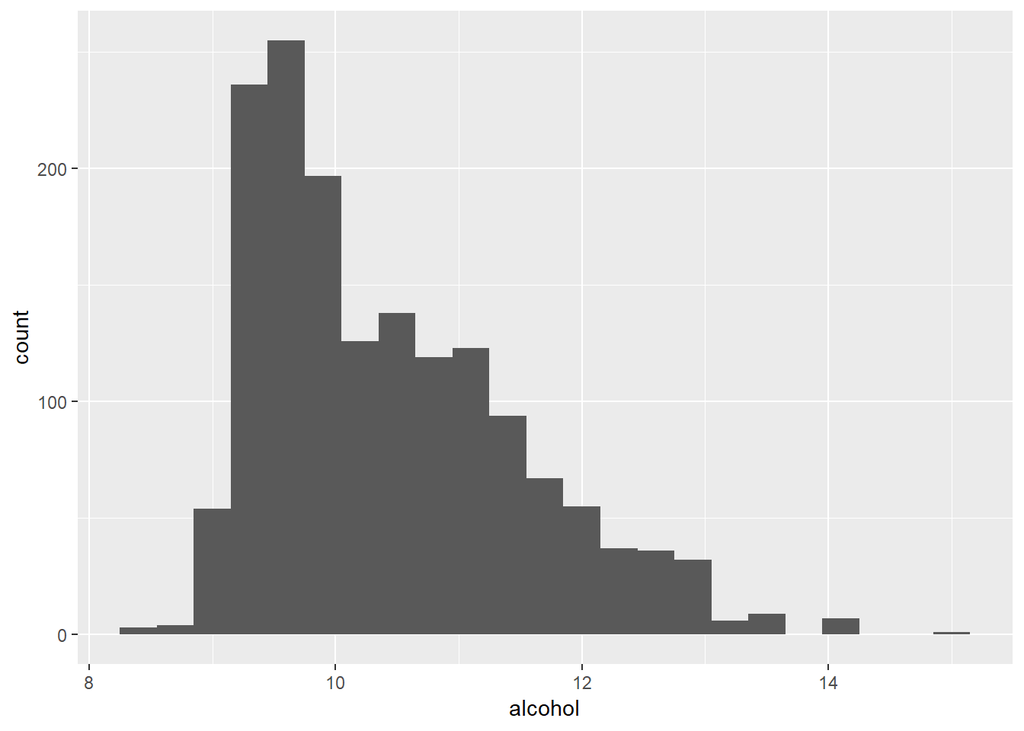

```
##    Min. 1st Qu.  Median    Mean 3rd Qu.    Max.
##    8.40    9.50   10.20   10.42   11.10   14.90
```

> The mean alcohol content of the wine is at 10% and it’s right-skewed distribution.

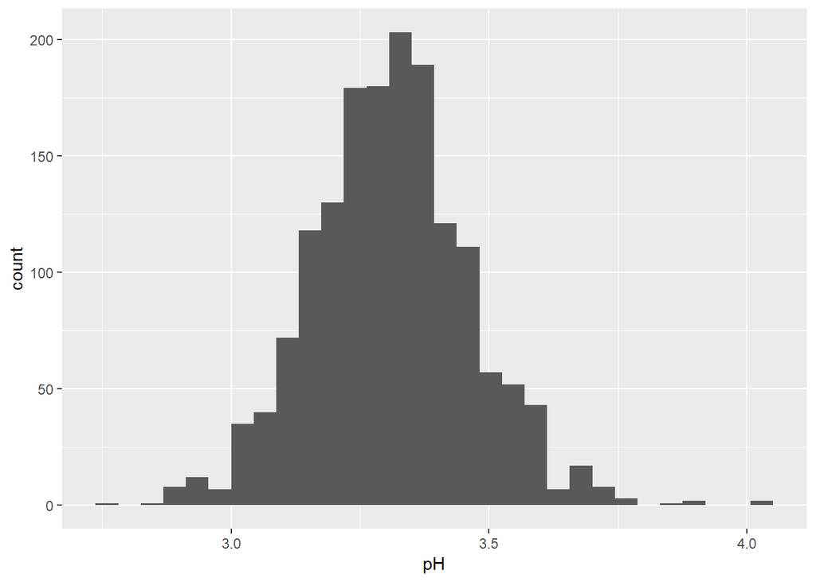

```
##    Min. 1st Qu.  Median    Mean 3rd Qu.    Max.
##   2.740   3.210   3.310   3.311   3.400   4.010
```

> on a scale from 0 (very acidic) to 14 (very basic); most wines are between 3-4 on the pH scale.

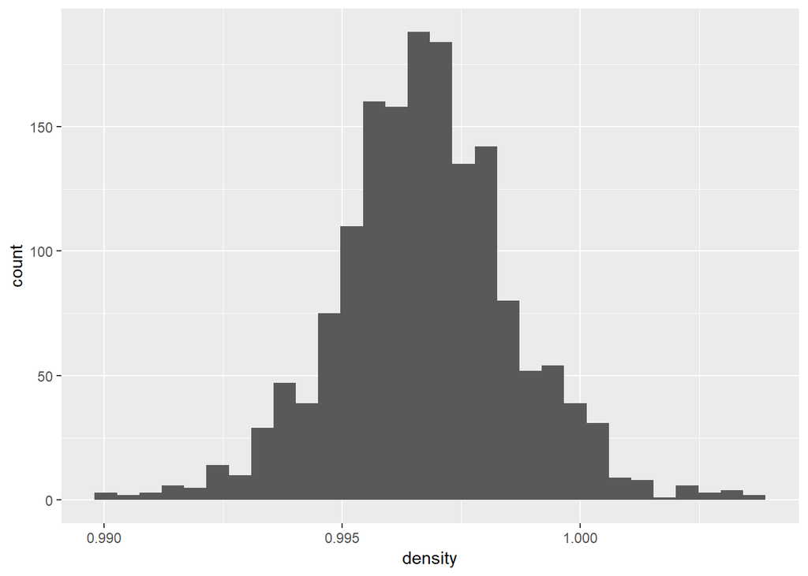

```
##    Min. 1st Qu.  Median    Mean 3rd Qu.    Max.
##  0.9901  0.9956  0.9968  0.9967  0.9978  1.0037
```

> the density of water is close to that of water depending on the percent alcohol and sugar content and we can see from the plot and the mean is 0.9967 .

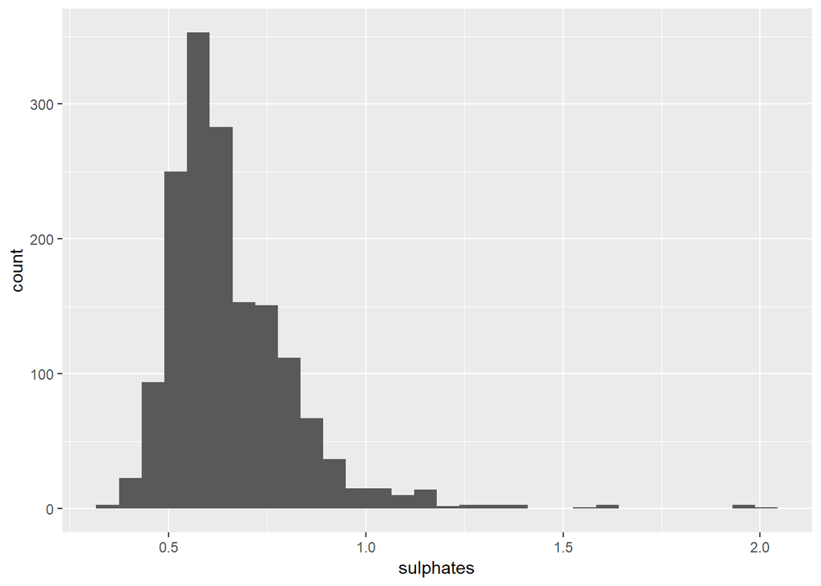

```
##    Min. 1st Qu.  Median    Mean 3rd Qu.    Max.
##  0.3300  0.5500  0.6200  0.6581  0.7300  2.0000
```

> Sulphates values above 1.5 are outliers.

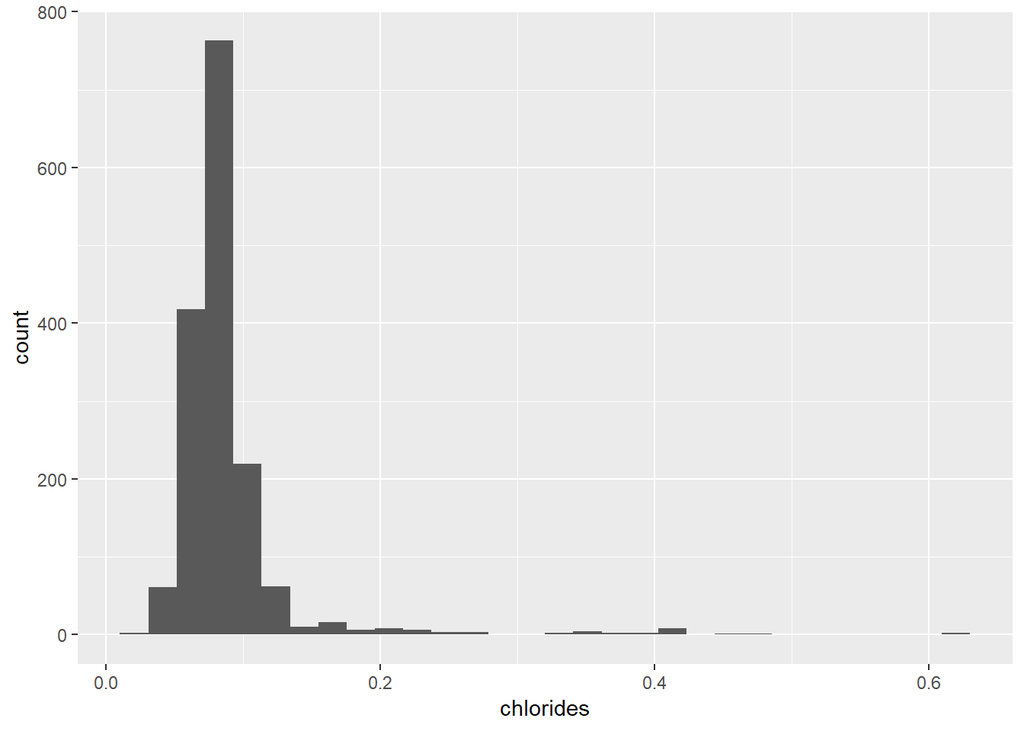

```
##    Min. 1st Qu.  Median    Mean 3rd Qu.    Max.
## 0.01200 0.07000 0.07900 0.08747 0.09000 0.61100
```

> chlorides is the amount of salt in the wine and chlorides more than 0.6 are outliers.

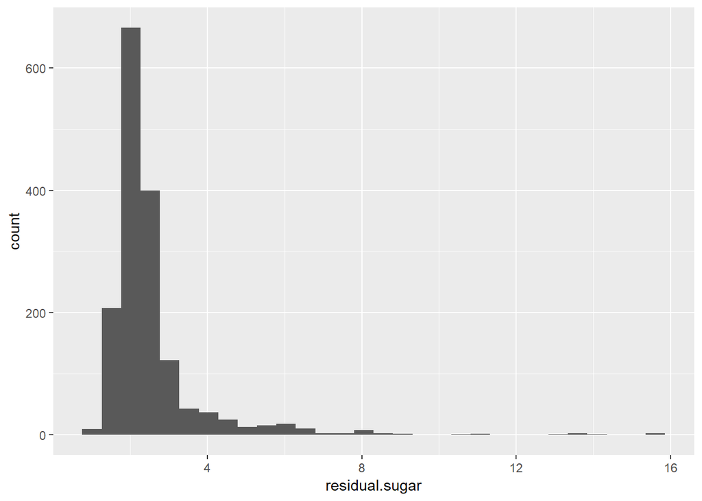

```
##    Min. 1st Qu.  Median    Mean 3rd Qu.    Max.
##   0.900   1.900   2.200   2.539   2.600  15.500
```

> the amount of sugar remaining after fermentation stops is around 2 grams/ 1 litre.

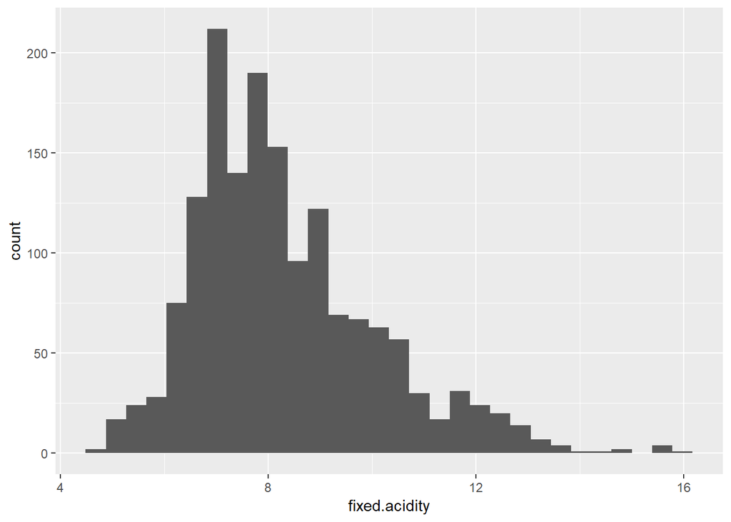

```
##    Min. 1st Qu.  Median    Mean 3rd Qu.    Max.
##    4.60    7.10    7.90    8.32    9.20   15.90
```

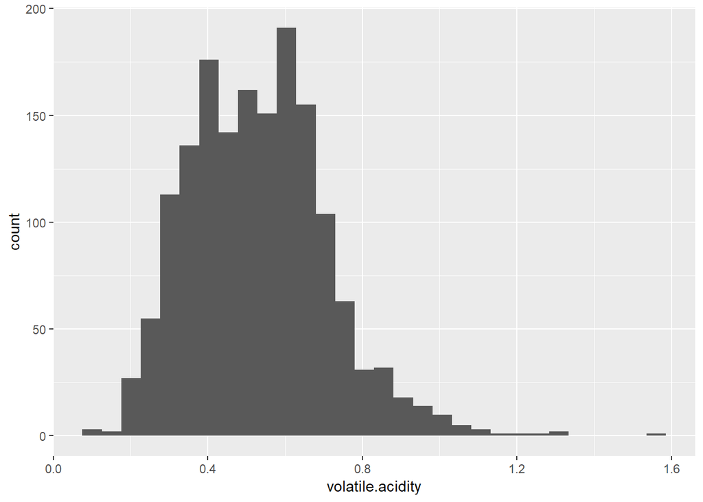

```
##    Min. 1st Qu.  Median    Mean 3rd Qu.    Max.
##  0.1200  0.3900  0.5200  0.5278  0.6400  1.5800
```

# Univariate Analysis

### What is the structure of your dataset?

Number of Instances:1599,Number of Attributes: 12.

1 - fixed acidity: most acids involved with wine or fixed or nonvolatile (do not evaporate readily).

2 - volatile acidity: the amount of acetic acid in wine, which at too high of levels can lead to an unpleasant, vinegar taste.

3 - citric acid: found in small quantities, citric acid can add ‘freshness’ and flavor to wines.

4 - residual sugar: the amount of sugar remaining after fermentation stops, it’s rare to find wines with less than 1 gram/liter and wines with greater than 45 grams/liter are considered sweet.

5 - chlorides: the amount of salt in the wine.

6 - free sulfur dioxide: the free form of SO2 exists in equilibrium between molecular SO2 (as a dissolved gas) and bisulfite ion; it prevents microbial growth and the oxidation of wine.

7 - total sulfur dioxide: amount of free and bound forms of S02; in low concentrations, SO2 is mostly undetectable in wine, but at free SO2 concentrations over 50 ppm, SO2 becomes evident in the nose and taste of wine.

8 - density: the density of water is close to that of water depending on the percent alcohol and sugar content.

9 - pH: describes how acidic or basic a wine is on a scale from 0 (very acidic) to 14 (very basic); most wines are between 3-4 on the pH scale.

10 - sulphates: a wine additive which can contribute to sulfur dioxide gas (S02) levels, wich acts as an antimicrobial and antioxidant.

11 - alcohol: the percent alcohol content of the wine.

12 - quality (score between 0 and 10).

#https://s3.amazonaws.com/udacity-hosted-downloads/ud651/wineQualityInfo.txt

### What is/are the main feature(s) of interest in your dataset?

The main features in the data set are quality , alcohol and residual sugar. I’d like to determine which features are best for predicting the the quality of the wine.

### What other features in the dataset do you think will help support your density, pH, aciditi“fixed or volatile”and chlorides can increase or decrease the quality of the wine .

### Did you create any new variables from existing variables in the dataset? not yet but i might group some variables in the Bivariate section.

### Of the features you investigated, were there any unusual distributions? there is no unusal disributions, most of them are normal or right-skewed distributions with some outliers.

# Bivariate Plots Section

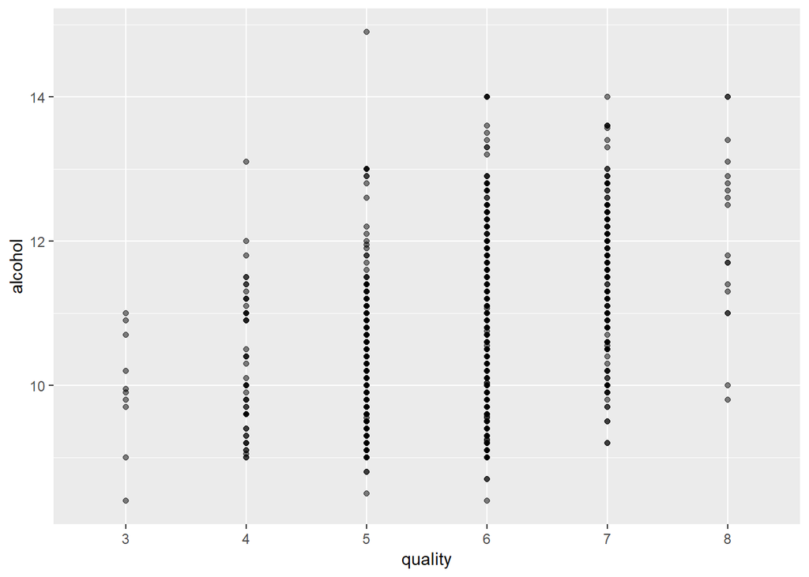

> From the scatter plot above we can see that low quality wine have a less percentage of alcohol in it, and as the quality increases we can see a small correlation between alcohol and the overall quality of the wine, however the highest quality of the wine doesn’t have the highest percentage of alcohol .

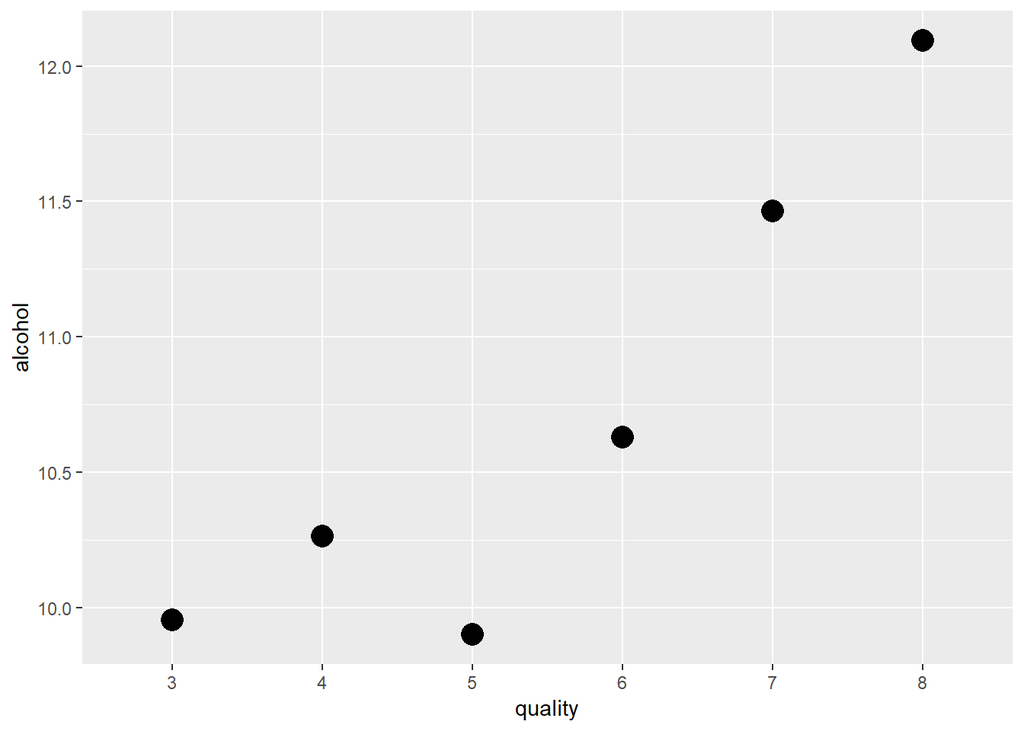

> by the mean alcohol values we can see a clearer picture of the alcohol vs quality and we can say that there is a correlation except for the level 5 quality .

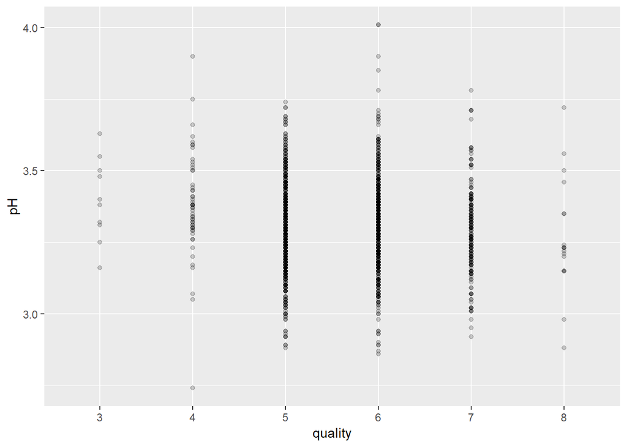

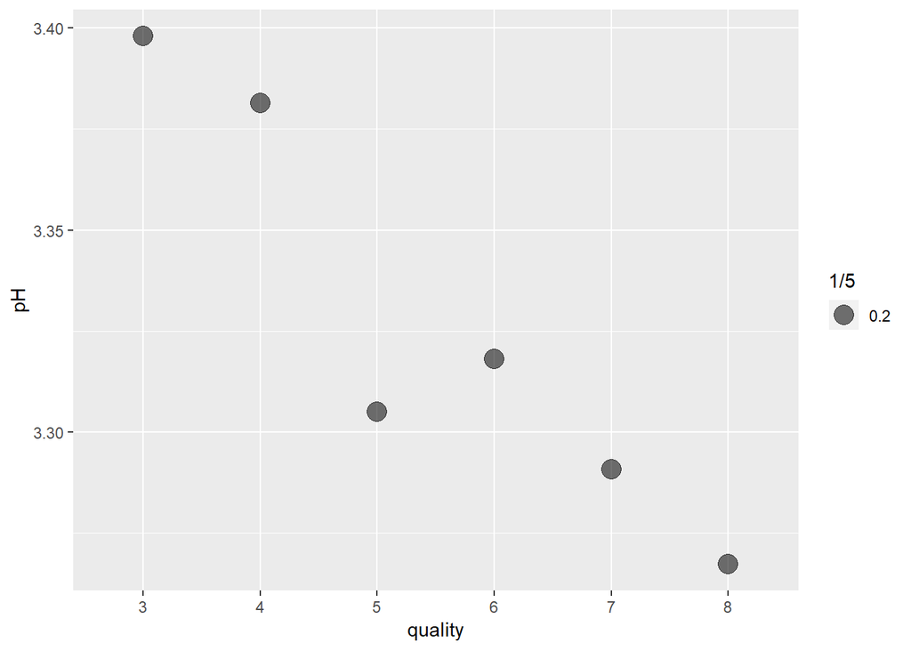

> with the mean pH we can see a negative relationship between pH and the quality of the wine except the level 5 quality like the alcohol too.

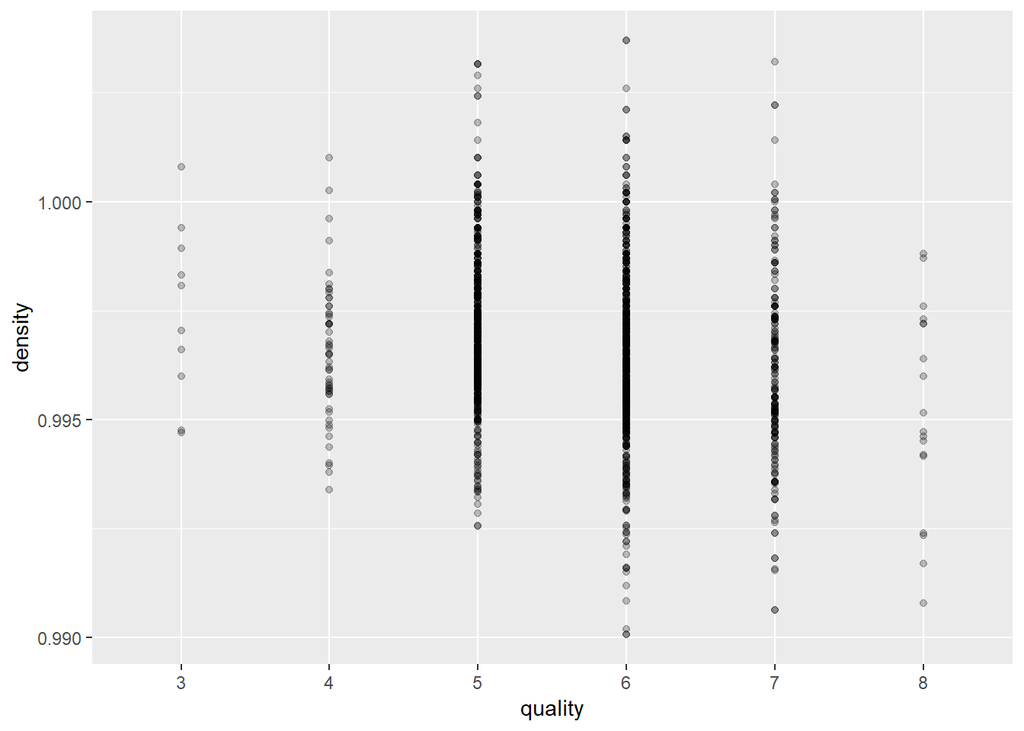

> the scatter plot above indecates that high quality wine have less density than low quaity or the average quality wine , however we might take a deeper look on other factors that might effect the quality beside the density .

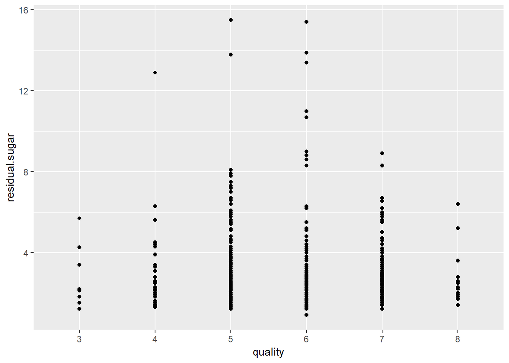

> both lowest and highest wine quality have alomost the same residual sugar values , with the some outliers in the middle .

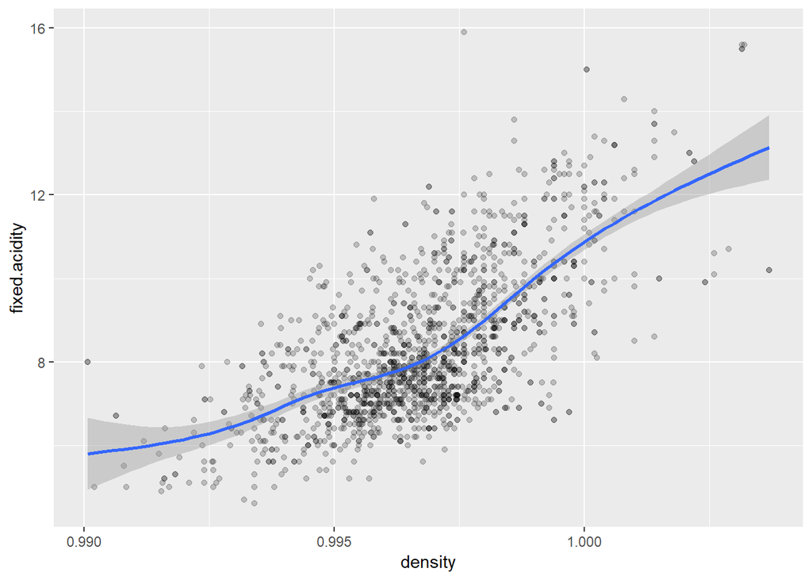

```
##
##  Pearson's product-moment correlation
##
## data:  df$density and df$fixed.acidity
## t = 35.877, df = 1597, p-value < 2.2e-16
## alternative hypothesis: true correlation is not equal to 0
## 95 percent confidence interval:
##  0.6399847 0.6943302
## sample estimates:
##       cor
## 0.6680473
```

> there is a moderate positive relationship between density and fixed acidlity .

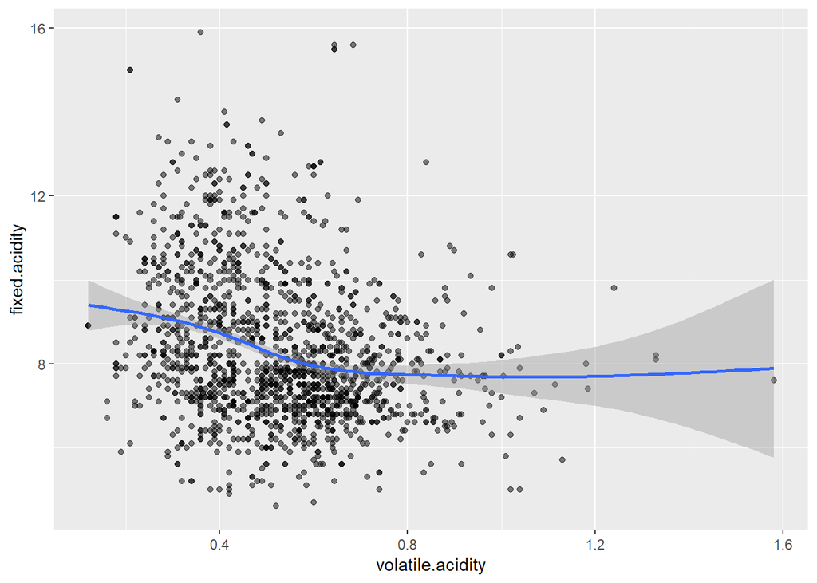

> no strong relationship between fixed acidlity and volatile acidlity .

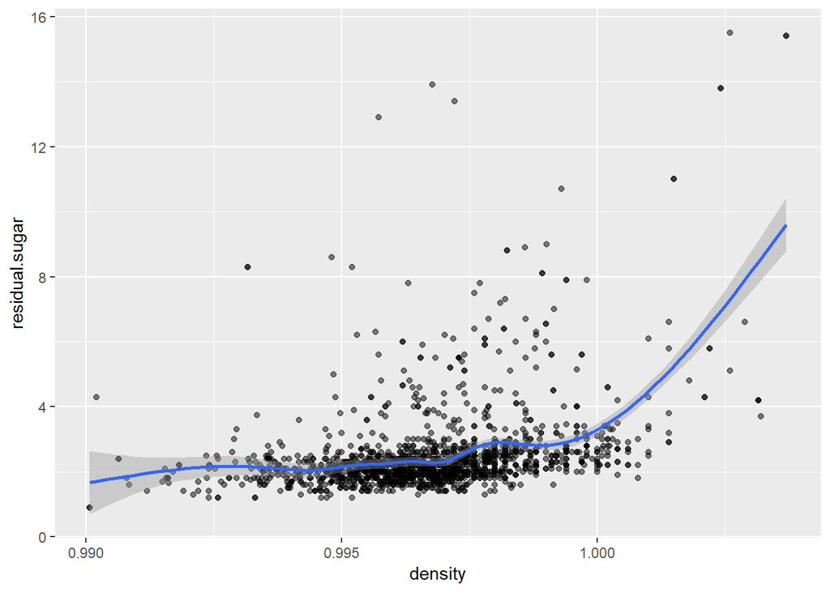

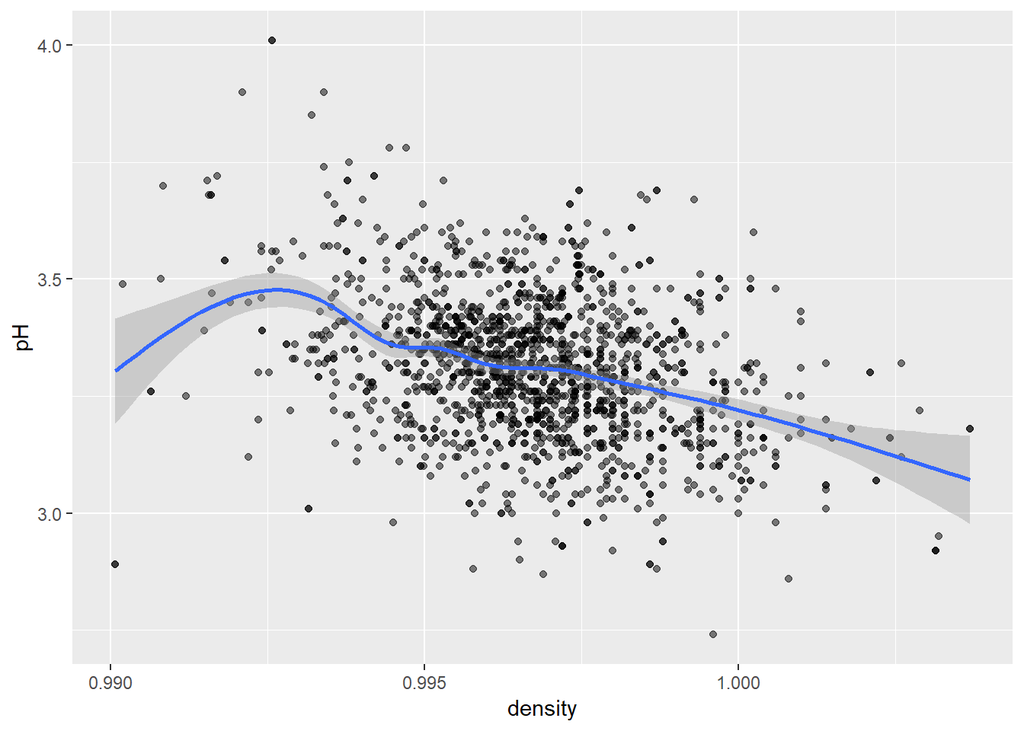

# Bivariate Analysis

### Talk about some of the relationships you observed in this part of the investigation. How did the feature(s) of interest vary with other features in the dataset?

> Quality compared to alcohol percentage, low quality wine have a less  
> percentage of alcohol in it, and as the quality increases we can see a small  
> correlation between alcohol and the overall quality of the wine, however  
> the highest quality of the wine doesn’t have the highest  
> percentage of alcohol .

> With The mean pH we can see a negative relationship between pH and  
> the quality of the wine.

> The high quality wine have less density than low quaity or the average quality wine.

> conmparing quality to residual sugar, both lowest and highest  
> wine quality have alomost the same residual sugar values , with the  
> some outliers in the middle .

### Did you observe any interesting relationships between the other features

> There is a moderate positive relationship between density and fixed acidlity .

> No strong relationship between fixed acidlity and volatile acidlity .

### What was the strongest relationship you found?

> The positive relationship between density and fixed acidlity .

# Multivariate Plots Section

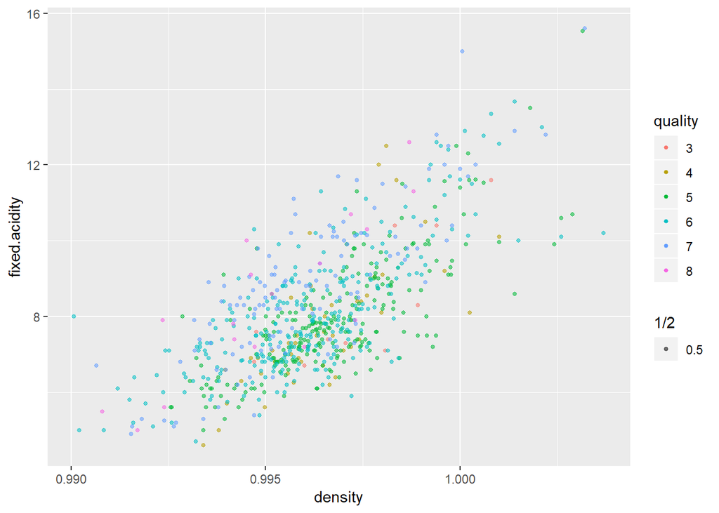

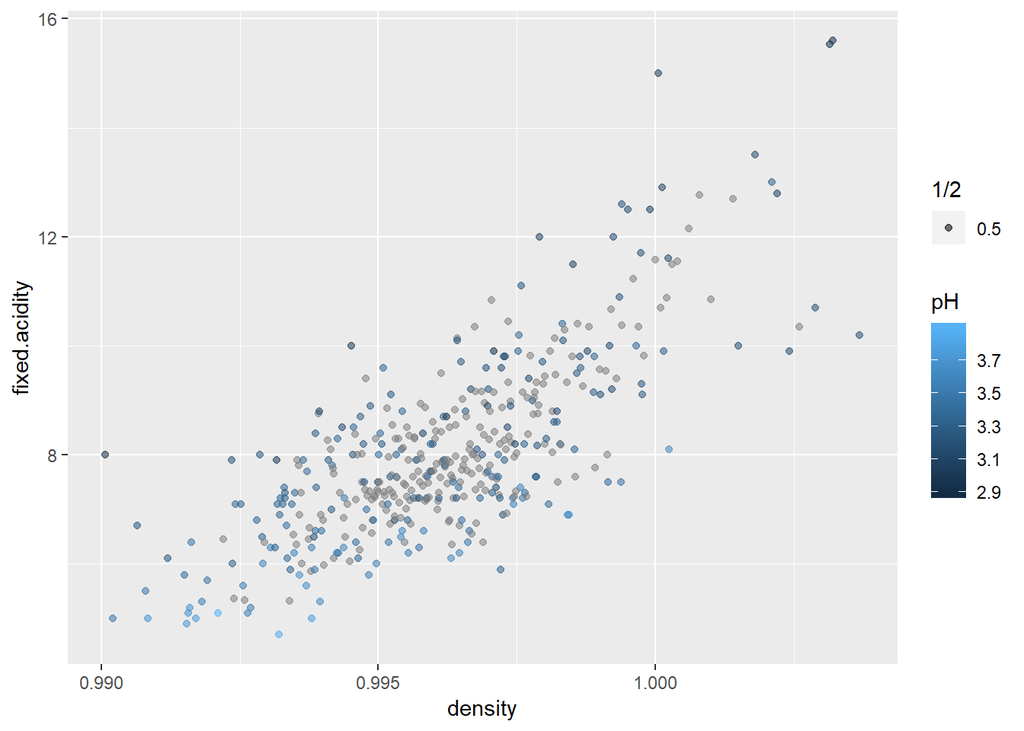

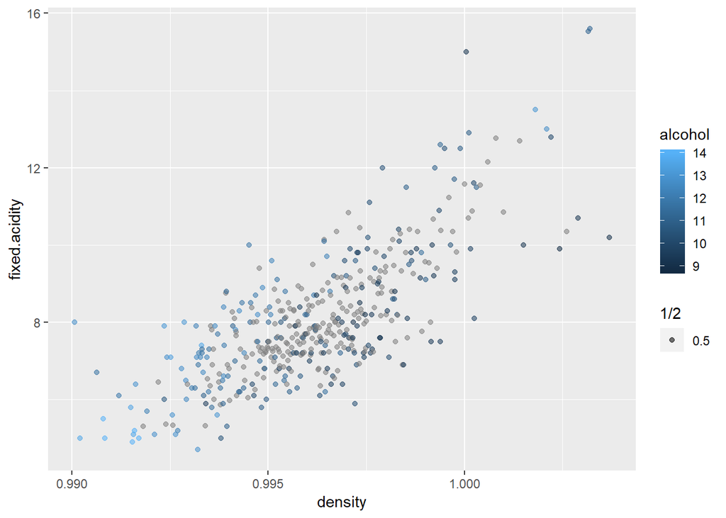

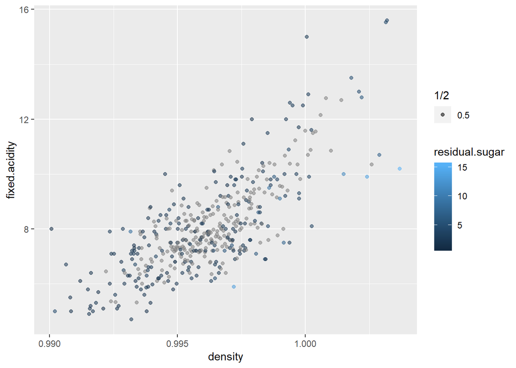

> When we added the quality to see it against the fixed acidity vs density , we can not find any corrlation between them and the quality,also alcohol,pH and residual sugar too.

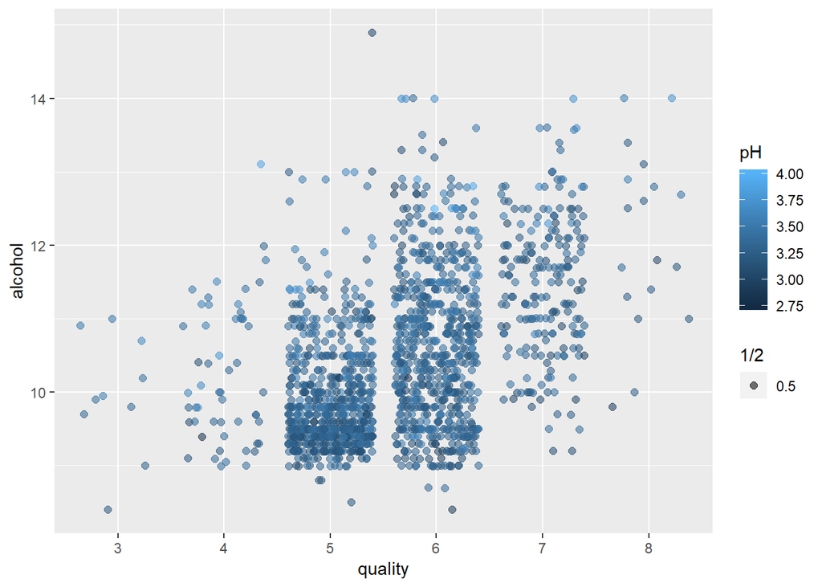

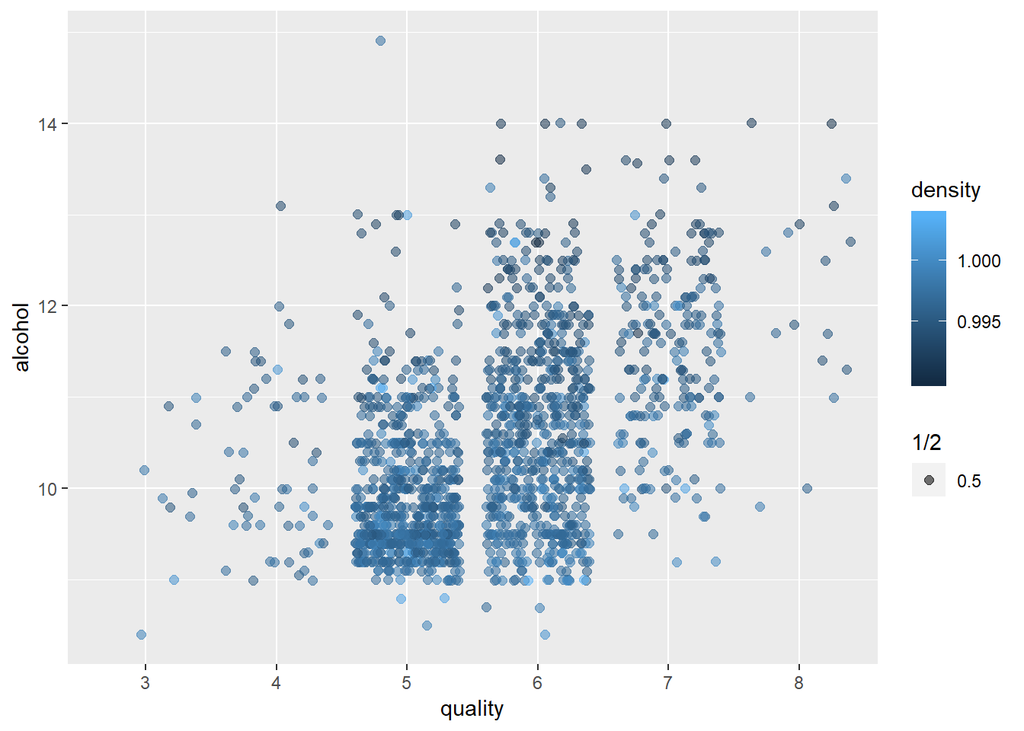

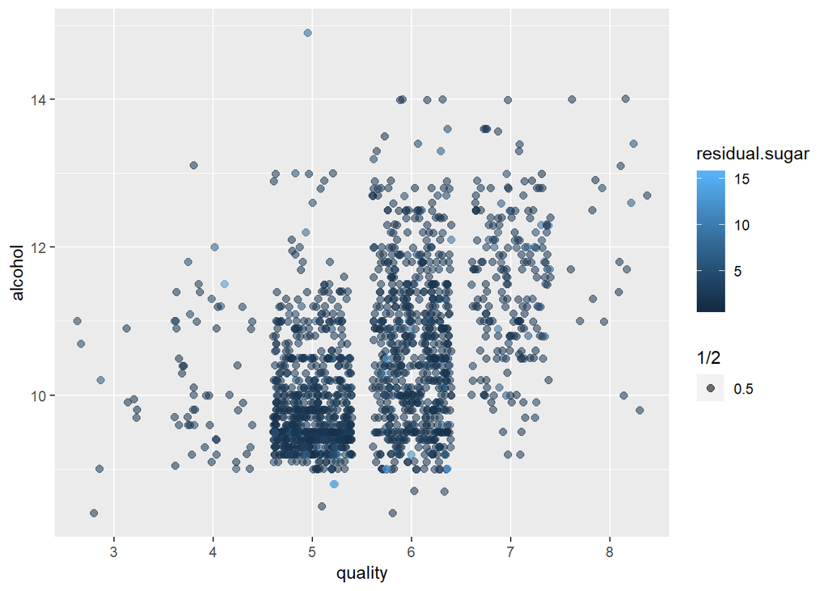

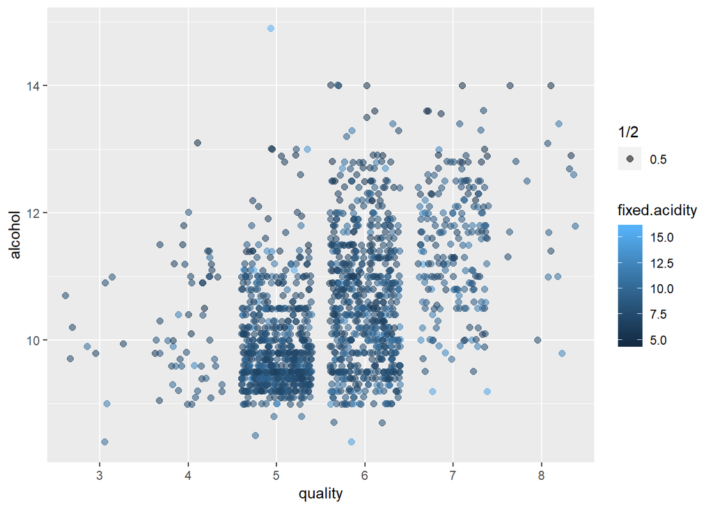

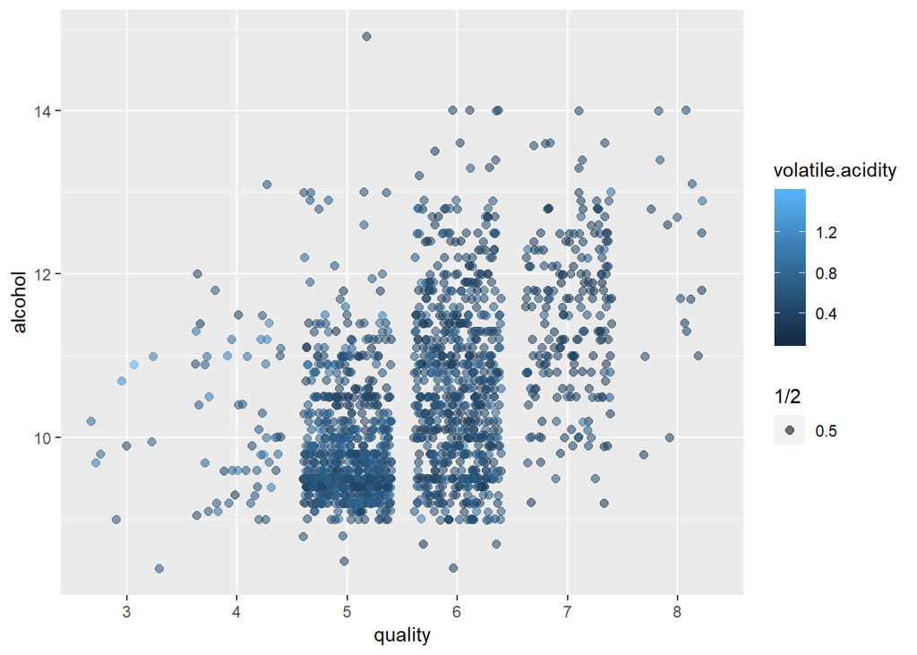

```
##
## Calls:
## m1: lm(formula = as.numeric(quality) ~ alcohol, data = df)
## m2: lm(formula = as.numeric(quality) ~ alcohol + pH, data = df)
## m3: lm(formula = as.numeric(quality) ~ alcohol + pH + density, data = df)
## m4: lm(formula = as.numeric(quality) ~ alcohol + pH + density + residual.sugar,
##     data = df)
## m5: lm(formula = as.numeric(quality) ~ alcohol + pH + density + residual.sugar +
##     fixed.acidity, data = df)
## m6: lm(formula = as.numeric(quality) ~ alcohol + pH + volatile.acidity,
##     data = df)
##
## ========================================================================================================
##                          m1            m2            m3            m4            m5            m6
## --------------------------------------------------------------------------------------------------------
##   (Intercept)          -0.125         2.426***    -11.593       -20.481        22.579         2.269***
##                        (0.175)       (0.387)      (11.293)      (12.444)      (21.430)       (0.369)
##   alcohol               0.361***      0.386***      0.397***      0.406***      0.361***      0.330***
##                        (0.017)       (0.017)       (0.019)       (0.020)       (0.027)       (0.017)
##   pH                                 -0.850***     -0.808***     -0.802***     -0.443*       -0.422***
##                                      (0.116)       (0.121)       (0.121)       (0.189)       (0.115)
##   density                                          13.811        22.673       -21.802
##                                                   (11.119)      (12.280)      (21.807)
##   residual.sugar                                                 -0.023        -0.006
##                                                                  (0.014)       (0.015)
##   fixed.acidity                                                                 0.061*
##                                                                                (0.025)
##   volatile.acidity                                                                           -1.279***
##                                                                                              (0.099)
## --------------------------------------------------------------------------------------------------------
##   R-squared             0.227         0.252         0.253         0.254         0.257         0.323
##   adj. R-squared        0.226         0.251         0.251         0.252         0.255         0.321
##   sigma                 0.710         0.699         0.699         0.698         0.697         0.665
##   F                   468.267       268.888       179.834       135.753       110.165       253.328
##   p                     0.000         0.000         0.000         0.000         0.000         0.000
##   Log-likelihood    -1721.057     -1694.466     -1693.693     -1692.252     -1689.205     -1615.101
##   Deviance            805.870       779.508       778.755       777.353       774.396       705.845
##   AIC                3448.114      3396.931      3397.385      3396.504      3392.411      3240.202
##   BIC                3464.245      3418.440      3424.271      3428.767      3430.051      3267.087
##   N                  1599          1599          1599          1599          1599          1599
## ========================================================================================================
```

# Multivariate Analysis

### Talk about some of the relationships you observed in this part of the investigation. Were there features that strengthened each other in terms of looking at your feature(s) of interest?

> there was no features that significantly strength each other in the  
> Multivariate Analysis.

> When we added the quality to see it against the fixed acidity vs density ,  
> we can not find any corrlation between them and the quality,also alcohol,pH  
> and residual sugar too.

### Were there any interesting or surprising interactions between features?

> The Multivariate Analysis we didn’t find any surprising interactions between  
> the main features.

### OPTIONAL: Did you create any models with your dataset? Discuss the strengths and limitations of your model.

> I have created a linear model to predict the quality of the wine with  
> the other features in the data set, and by looking at the results we can  
> tell that it only predicts 32% of the quality which is not that significant.

# Final Plots and Summary

### Plot One

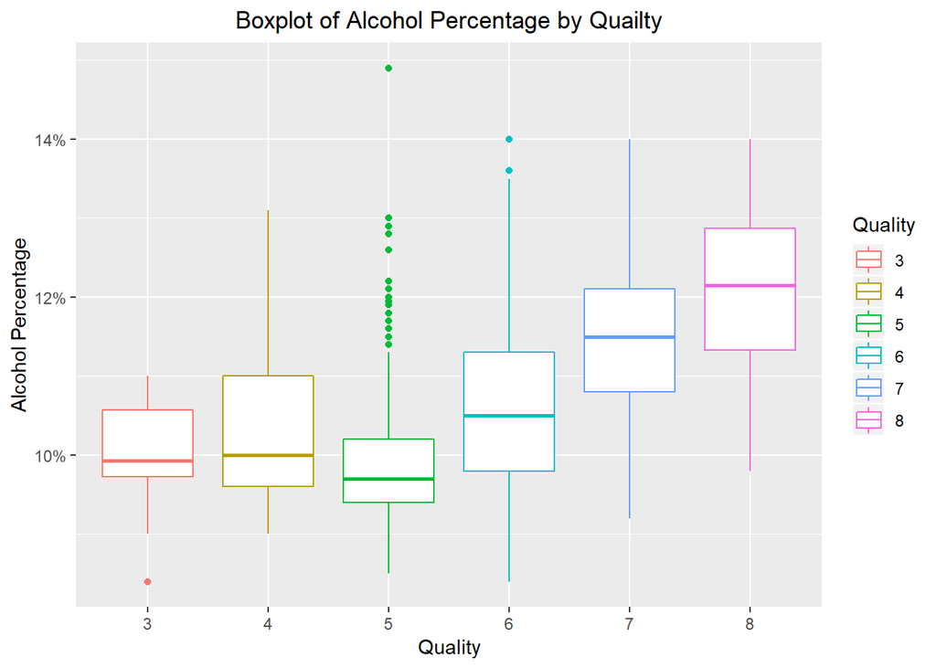

### Plot Two

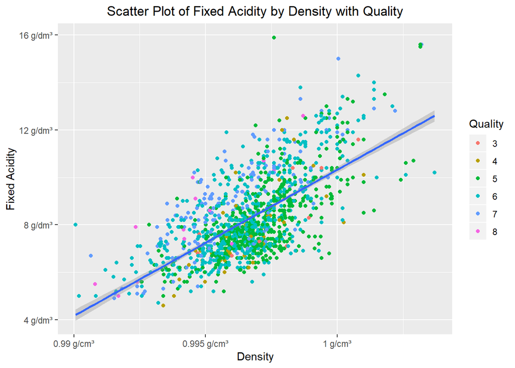

### Description Two

> this scatter plot shows the correlation between Fixed Acidity and  
> the Denisty, and there is a modrete positive relationship between them,  
> however when we add the quality to the plot we can see that quality 5 and 6  
> are the most common .

### Plot Three

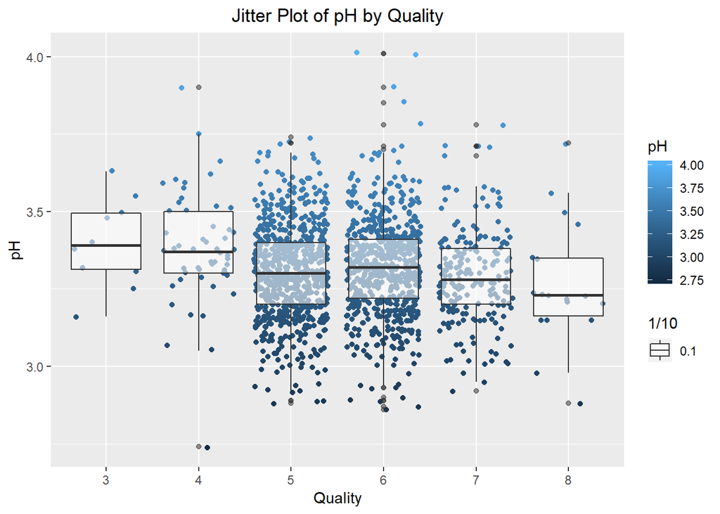

# Reflection

### Sources

Aging of wine https://en.wikipedia.org/wiki/Aging_of_wine. adding the % sgin to the plot https://stackoverflow.com/questions/35967047/appending-symbol-with-y-axis-values-in-ggplot2. changing the legend name https://stackoverflow.com/questions/33398033/change-ggplot-legend-title. adjusting to plot title to the cener of the plot https://stackoverflow.com/questions/40675778/center-plot-title-in-ggplot2.